*The data needed to estimate dinosaur speed.*

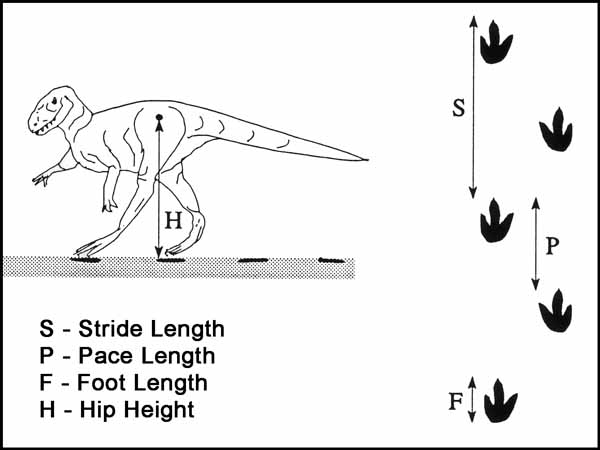

How fast did dinosaurs move? In order to answer this question, researchers have examined dinosaurs footprints, particularly the distance between those of the same foot, an observation known as stride length. In mammals, stride length correlates with speed. Therefore, the longer the stride, the higher the speed of the specimen. As dinosaurs walk with their feet directly under them similar to mammals, researchers have tentatively generalized observations of stride length in mammals to those in dinosaurs. Further, researchers have also been able to estimate dinosaurs leg length (also known as hip height) from footprint length, which can range from about one inch to six feet in length. On average, a dinosaurs’ footprint length relates to about a fourth of its leg length. Given both stride length and leg length, we can better estimate dinosaur speed.

Findings reveal that large sauropods walked at about 2.24 miles per hour, an astonishingly slow pace for a creature of their size. Yet, large bipedal dinosaurs were not much faster, clocking in at roughly 5mph on average. Most of the large dinosaur footprints are flat and well-defined, suggesting they mainly traveled by walking, likely because of their considerable weight. But, many of the smaller dinosaur footprints are more spread out and faded around the edges, indicating a tendency to run. One of the fastest groups of dinosaurs, the theropods known as Ornithomimosauria, could run at 27mph. The speed of these ostrich-like dinosaurs, though, remains identical to that recorded by the fastest human. In class, we learned that the fastest dinosaurs were the small theropods known as Compsognathus, capable of running up to about 40mph. By comparison, this genus of dinosaurs would trail behind the fastest horse, recorded as having sprinted at 55mph.